# Sales_Trend_Analysis

### Q4. Are there any seasonal trends in sales or profit across quarters and years?

**Visualization:**

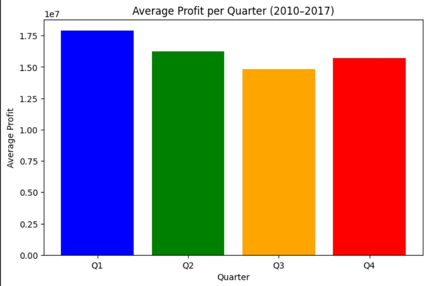

**Analysis:**

#### Analysis: Average Total Profit per Quarter (2010–2017)

The updated bar chart shows that **Q1 delivers the highest average total profit**, followed by Q2, while Q3 lags behind and Q4 partially recovers.

- **Q1**: Strongest quarter, with total profit reaching close to 18M.
- **Q2**: Solid performance, averaging around 16M, slightly below Q1.
- **Q3**: Weakest quarter, at around 15M, indicating softer demand or rising costs mid-year.
- **Q4**: Shows a rebound above Q3 (around 15.8M), but still below Q1–Q2.

**Key Insights:**

**Business Questions to Explore Further:**

- What drives the strong Q1 and Q2 performance—demand timing, procurement cycles, or regional market behavior?
- Why is Q3 structurally weak—lower consumer demand, supply chain constraints, or external market conditions?
- Should the company **reallocate promotional and marketing budgets from Q4 to Q1–Q2** to maximize return on investment?

### Q5. How is the distribution of orders across sub-regions within Europe?

**Visualization:**

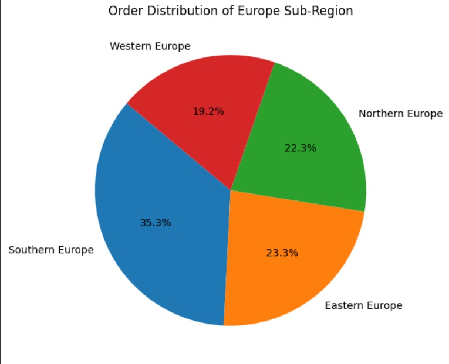

**Analysis:**

### Analysis: Order Distribution of Europe Sub-Region

The pie chart illustrates the distribution of orders across European sub-regions. **Southern Europe dominates order volume**, followed by Eastern and Northern Europe, while Western Europe trails behind.

- **Southern Europe (35.3%)**: Largest contributor, indicating strong demand and customer base in this sub-region.
- **Eastern Europe (23.3%)**: Solid share, reflecting consistent engagement.
- **Northern Europe (22.3%)**: Comparable to Eastern Europe, but slightly smaller.
- **Western Europe (19.2%)**: The smallest share, showing weaker order activity.

**Key Insights:**

1. Southern Europe is the primary driver of European order volume.
2. Eastern and Northern Europe contribute almost equally, showing balanced mid-level demand.
3. Western Europe underperforms, suggesting either market saturation, lower engagement, or limited reach.

**Business Questions to Explore Further:**

- What factors are driving Southern Europe’s dominance—population size, purchasing power, or marketing effectiveness?
- Why is Western Europe lagging behind despite being a traditionally strong market?
- Should the company invest more in Western Europe to boost its performance, or double down on the high-growth potential of Southern Europe?